# Let’s Predict Your Party!

Using machine learning to predict political affiliation in the United States.

Abigail Salle

Fall 2022

## Introduction

The goal of this project is to predict an adult American’s political affiliation based on certain self-claimed demographics. More specifically, I wish to predict whether a person would align with the Democratic Party or Republican Party based off of their age, sex, education, race, etc.

### The Different Parties

The Democratic Party  
The Democratic Party is one of the two main political parties in the United States.  
According to their official site, they are “fighting for a brighter, more equal future: rolling up [their] sleeves and organizing everywhere to build a better America for all.”  
Their platform includes universal healthcare, gun control, bodily autonomy, environmental justice, and equal & equitable opportunities for all.  
https://democrats.org  
The Republican Party  
The Republican Party is the other main political party in the United States.  
According to their official site, they believe in “liberty, economic prosperity, preserving American values and traditions, and restoring the American dream for every citizen of this great nation.”  
Their platform includes lowering taxes, free-market capitalism, securing American borders, upholding traditional & Constitutional values, and social conservatism.  
https://www.rnc.org

### Why is this model useful?

It could be useful to be able to predict political affiliation so parties or candidates know who to gear their campaigns towards. They can look at the typical trends and better plan how to move forward with their goals.

## Getting Data Ready

### Loading Packages

I will first load all of the necessary packages for the entire project. I started with the packages I assumed I would need, then throughout working on the project I came back here to add any additonal needed.

```r
# load packages
library(tidyverse)
library(tidymodels)
tidymodels_prefer()
library(zoo)
library(base)
library(inspectdf)
library(stats)
library(rsample)
library(discrim)
library(poissonreg)
library(corrr)
library(corrplot)
library(klaR)
library(janitor)
library(randomForest)
library(xgboost)
library(kernlab)
library(kknn)
```

### Loading Data

I obtained my data from Harvard Dataverse, specifically the 2020 Cooperative Election Study Common Content. It is too large to upload to Github but it is copied below.  
https://dataverse.harvard.edu/dataset.xhtml?persistentId=doi%3A10.7910/DVN/E9N6PH.  
I have downloaded it to my computer, uploaded it on R, and it is now here:

```r
data <- read.csv("CES20_Common_OUTPUT_vv.csv")
```

The data package also includes a survey of 61,000 American adults and a report that explains the questions and details of the survey. Some of the questions include asking participants their birth year, sex, martial status, military status, family income, etc. Aside from birth year, all of the questions are “multiple choice” format as opposed to writing in their answers. This allowed them to group all of the answers as integers, and then provide a key to what it all means, which I will also recreate in my codebook.

### Cleaning Data

While initially there are hundreds of predictor variables, I plan on using only 16. I chose these particular variables because I think they will be most useful with prediction and are most relevant to the study.  
Because participants enclosed their birth year and not their age, I am creating a variable called “age” approximated by subtracting their birth year from our current year. I will then eliminate the “birthyr” variable.

```r
data2 <- data[,c(9,10,11,12,44,56,57,127,239,242,249,250,253,256,274,278,325)]
  # 239 is response variable
age <- 2022 - data2$birthyr # estimate age from given birth year
data3 <- cbind(data2, age) # include it in set
data4 <- data3[,-1] # remove birthyr
```

Of the 61,000 observations and 17 variables, there were 465 missing values.  
To fix this issue, I will be filling in the missing values with the column’s mean value.  
I feel that there are enough observations that using the mean will be an accurate estimate of what each missing value could have been. This is a convenient way to solve the issue because I do not want to just eliminate those missing pieces.

```r
sum(is.na(data4)) # check missing
```

```
## [1] 465
```

```r
data5 <- na.aggregate(data4) # fill
sum(is.na(data5)) # good to go
```

```
## [1] 0
```

I am turning all of the predictors into factors, except “age”, because those are all categorical variables but R initially viewed them as numerical. They must be seen as factors because they are not continuous; for example, there cannot be a race of 2.5. For now, I will hold off on changing ‘pid3’ to factor because first I’ll need to edit it.

```r
# change into factors
data6 <- data5
data6$gender <- as.factor(data6$gender)
data6$educ <- as.factor(data6$educ)
data6$race <- as.factor(data6$race)
data6$marstat <- as.factor(data6$marstat)
data6$inputstate <- as.factor(data6$inputstate)
data6$votereg <- as.factor(data6$votereg)
data6$CC20_309e <- as.factor(data6$CC20_309e)
data6$ownhome <- as.factor(data6$ownhome)
data6$cit1 <- as.factor(data6$cit1)
data6$immstat <- as.factor(data6$immstat)
data6$employ <- as.factor(data6$employ)
data6$urbancity <- as.factor(data6$urbancity)
data6$sexuality <- as.factor(data6$sexuality)
data6$pew_religimp <- as.factor(data6$pew_religimp)
data6$faminc_new <- as.factor(data6$faminc_new)
# checking to make sure all but 'age' are factors
inspect_types(data6)
```

```
## # A tibble: 2 × 4
##   type      cnt  pcnt col_name
##   <chr>   <int> <dbl> <named list>
## 1 factor     15  88.2 <chr [15]>
## 2 numeric     2  11.8 <chr [2]>
```

Finally, I have decided to only keep participants who classify themselves as Democratic or Republican in the pid3 variable. This is because I feel like accuracy will be lost trying to predict Independent or Other, and for the sake of this project I am only focusing on the two main parties.  
Additionally, pid3 is our response variable and I want supervised learning and as accurate as possible, and so I think only keeping those two possibilities is best. This means we now have 37,969 observations, which is still significant.  
Now I can also turn pid3 into a factor.

```r
# only keeping democrat or republican
data7<-data6[!(data6$pid3==3 | data6$pid3==4 | data6$pid3==5),]
dim(data7)
```

```
## [1] 37969    17
```

```r
data7$pid3 <- as.factor(data7$pid3)
```

### Splitting Data

Prior to EDA, I will be splitting my data. 80% will go into the training set and 20% for the testing set. I will use stratified random sampling on the response variable “pid3” to ensure the distribution of Democrat and Republican is fair. I am splitting before EDA to ensure I do not see any of the testing data before it is time to evaluate. There are now over 30,000 observations in the training dataset and over 7,000 in the testing set, which seems appropriate.

```r
# split the data

set.seed(0120)

polparty_split <- initial_split(data7, prop = 0.80, strata = pid3)

polparty_train <- training(polparty_split)
polparty_test <- testing(polparty_split)
```

## Exploratory Data Analysis

Before I can be making and running models I will explore the data that I have to better understand it. I will start by checking out the predictor variables and seeing the frequency of the different levels of them.  
Then I really want to look into my response variable, pid3. First I will just see the distribution of it alone. Then I will break it down to see the distribution based on two predictor variables that I guess will be important, education and sex.

### Frequency Chart

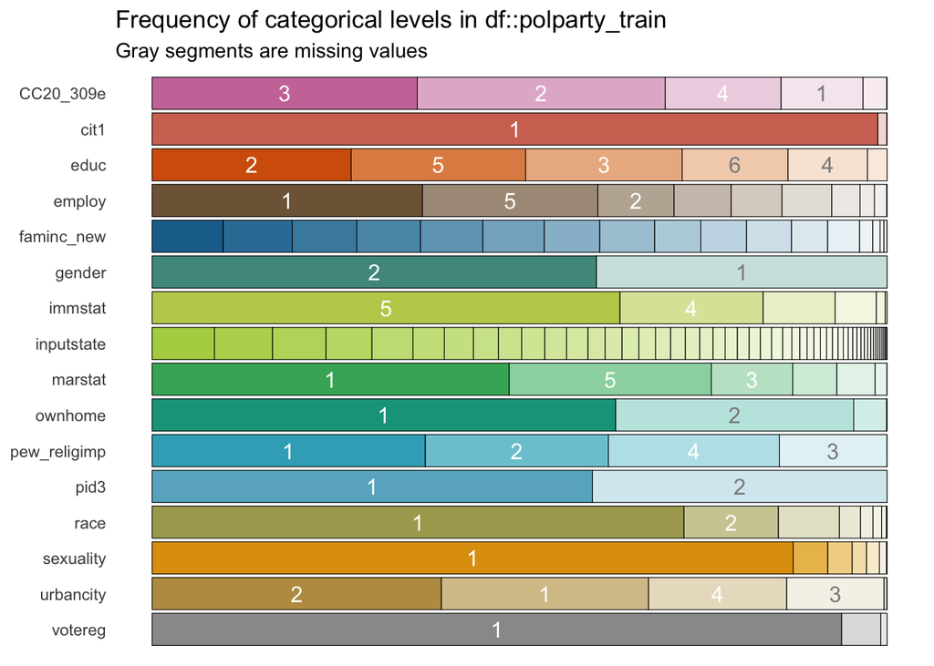

```r
x <- inspect_cat(polparty_train)
show_plot(x, col_palette=1)
```

Here I really just wanted to take a look at our predictors and how they are distributed. I can see that while education and state, for example, are pretty equally spread between answers, there is a big skew for answers on registration status and race. I think that is very important to note for later on when I try to see how impactful the predictors are on our response.

### Barplots

Distribution of our Response Variable:

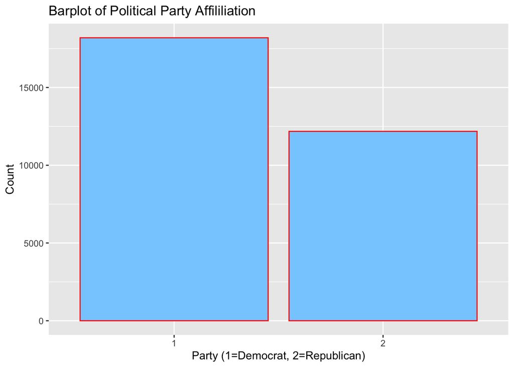

```r
#plot
ggplot(polparty_train, aes(pid3)) +
  geom_bar(fill = "skyblue1", col="red") +
  labs( title = "Barplot of Political Party Affililiation",
        x="Party (1=Democrat, 2=Republican)",
        y="Count" )
```

From this I learn that there are more Democrats than Republicans in our data. I wish it had been a more fair split, but now I just know to look at percentages at predicting instead of just count since they do not start at the same amount.

Now, let’s look at the distribution of response by education:

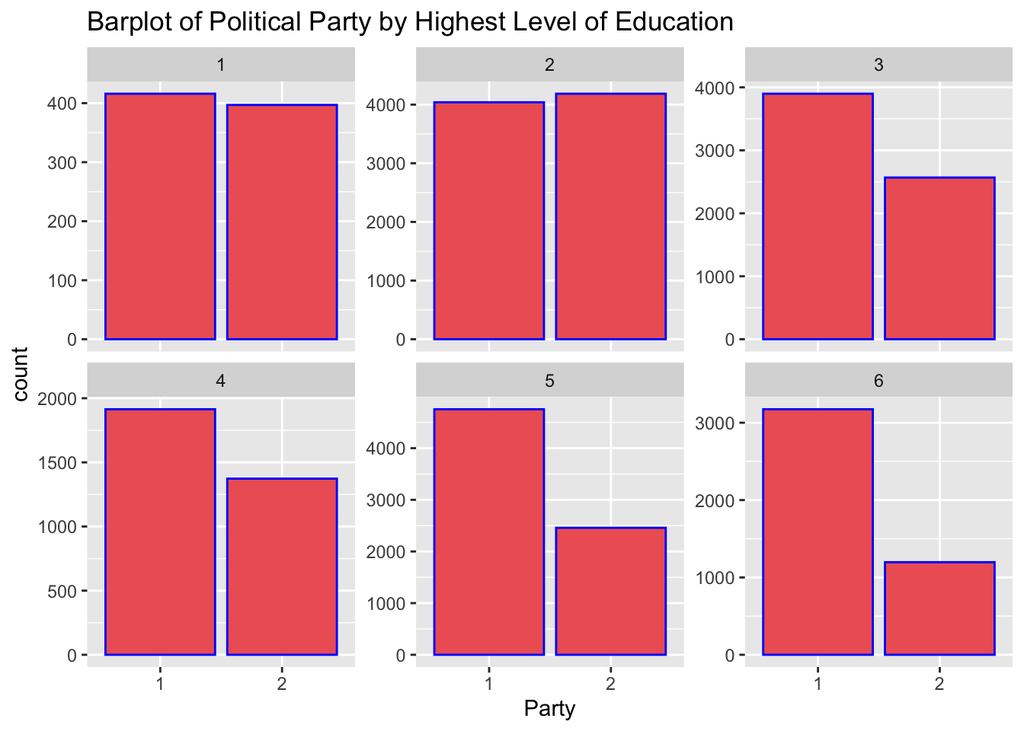

```r
 # plot
ggplot(polparty_train, aes(pid3)) +
  geom_bar(color = "blue", fill="indianred2") +
  facet_wrap(~educ, scales = "free_y") +
  labs( title = "Barplot of Political Party by Highest Level of Education" ,
        x= "Party" )
```

Finally, let’s look at the distribution of response by sex:

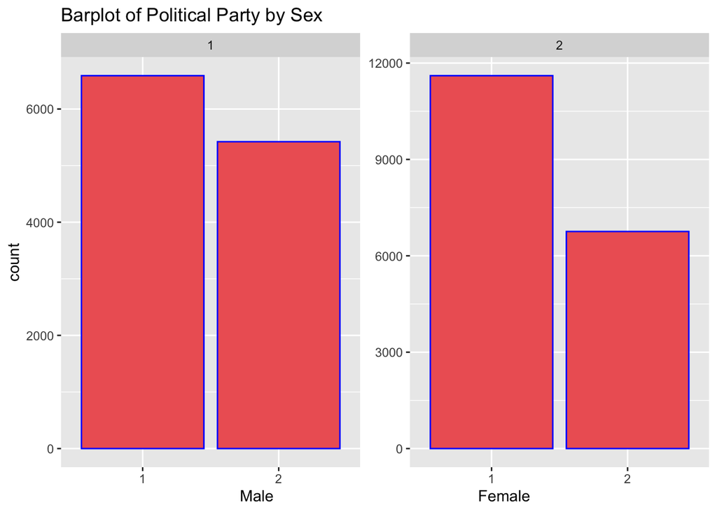

```r
# plot
ggplot(polparty_train, aes(pid3)) +
  geom_bar(color = "blue", fill="indianred2") +
  facet_wrap(~gender, scales = "free_y") +
  labs( title = "Barplot of Political Party by Sex" ,
        x= "Male                                               Female" )
```

This is not as telling to me. In both sexes there are more Democrats than Republicans, but since it was not evenly distributed before this filter I do not think that means much and I do not think this tells us whether sex significantly impacts affiliation.

## Model Building

Now it is time to start model building! I will create 5 models: Logistic Regression, Pure Lasso, K Nearest Neighbors, Random Forest, and Boosted Trees.  
BUT FIRST, we have to take care of a few steps…

### Recipe

I have to create a recipe to allow me to move onto model fitting. I plug in my response variable and am using all of my predictors to affect this one recipe. I have to dummy my qualitative variables and will center and scale my recipe for convenience.

```r
polparty_recipe <- recipe(pid3 ~ gender + educ + race + marstat +
                          inputstate + votereg + CC20_309e + ownhome +
                          cit1 + immstat + employ + urbancity +
                          sexuality + pew_religimp + faminc_new + age,
                          data = polparty_train) %>%
  step_dummy(all_nominal_predictors()) %>%
  step_normalize(all_numeric(), -all_outcomes())

#polparty_recipe %>%
 # prep() %>%
 # juice()
```

### Cross-Validation Folding

We will use cross validation with 5 folds and stratify it across our response variable.

```r
set.seed(0120)
polparty_fold <- vfold_cv(polparty_train, v = 5, strata = pid3)
polparty_fold
```

```
## #  5-fold cross-validation using stratification
## # A tibble: 5 × 2
##   splits               id
##   <list>               <chr>
## 1 <split [24299/6076]> Fold1
## 2 <split [24300/6075]> Fold2
## 3 <split [24300/6075]> Fold3
## 4 <split [24300/6075]> Fold4
## 5 <split [24301/6074]> Fold5
```

And now, model time!  
Since this is a binary classification problem, I have decided that the metric I will be comparing for all of my models is roc_auc.

### Logistic Regression Model

My first model I will do is Logistic Regression:

```r
# model
 log_reg <- logistic_reg() %>%
   set_engine("glm") %>%
   set_mode("classification")

# workflow
log_wkflow <- workflow() %>%
  add_recipe(polparty_recipe) %>%
  add_model(log_reg)
```

Let’s see how it did:

```r
log_results <- read_rds(file="project_log_results.rds")

collect_metrics(log_results)
```

```
## # A tibble: 2 × 6
##   .metric  .estimator  mean     n std_err .config
##   <chr>    <chr>      <dbl> <int>   <dbl> <chr>
## 1 accuracy binary     0.760     5 0.00209 Preprocessor1_Model1
## 2 roc_auc  binary     0.831     5 0.00180 Preprocessor1_Model1
```

```r
log_fit <- fit(log_wkflow, polparty_train)
```

Here we see that the model performed with an roc_auc of roughly 83% on the training data.  
This to me was higher than expected for my first model and I am pleased with it, especially with it being such a simple model.

### Lasso Model

Next up, Lasso!

```r
# model
lasso_spec <- multinom_reg(mode="classification",
                           engine = "glmnet",
                           penalty = tune(),
                           mixture = 1)

# workflow
lasso_wf <- workflow() %>%
  add_recipe(polparty_recipe) %>%
  add_model(lasso_spec)

# grid
param_grid_lasso <- grid_regular(penalty(range = c(-5, 5)), levels = 10)
```

```r
# tune grid

tune_res_lasso <- tune_grid(
  lasso_wf,
  resamples = polparty_fold,
  grid = param_grid_lasso
)

write_rds(tune_res_lasso, file="project_lasso_results.rds")
```

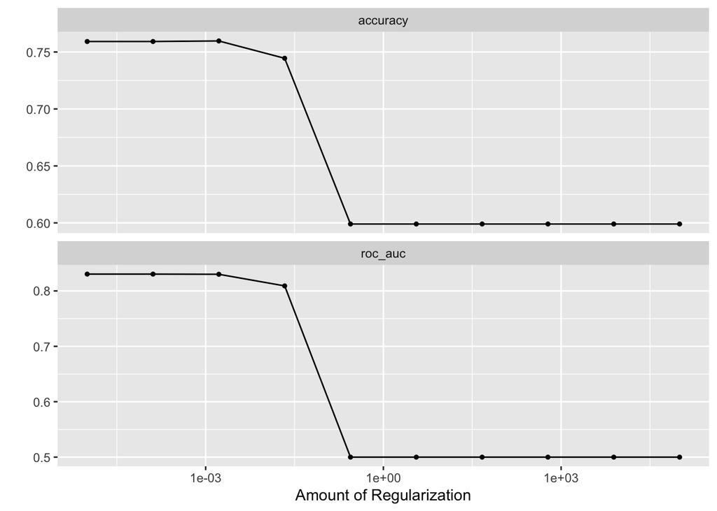

```r
# print results
lasso_results <- read_rds(file="project_lasso_results.rds")
lasso_results %>%
  autoplot()
```

I will just looking at the roc_auc curve to stay consistent..  
We see that smaller amounts of regularization give a greater value of roc_auc, which is wanted. The peak appears to be just above 0.8

### K Nearest Neighbors

Now I will create a KNN model:

```r
# model
knn_spec <- nearest_neighbor(neighbors=tune()) %>%
  set_engine("kknn") %>%
  set_mode("classification")
  translate(knn_spec)
```

```
## K-Nearest Neighbor Model Specification (classification)
##
## Main Arguments:
##   neighbors = tune()
##
## Computational engine: kknn
##
## Model fit template:
## kknn::train.kknn(formula = missing_arg(), data = missing_arg(),
##     ks = min_rows(tune(), data, 5))
```

- I am using code help from https://uo-datasci-specialization.github.io/c4-ml-fall-2020/slides/w6p1-knn/w6p1.pdf

```r
# tune model
tune_res_knn <- tune::tune_grid(
  knn_spec,
  preprocessor = polparty_recipe,
  resamples = polparty_fold,
  control = tune::control_resamples(save_pred = TRUE)
)

write_rds(tune_res_knn, file="project_knn_results.rds")
```

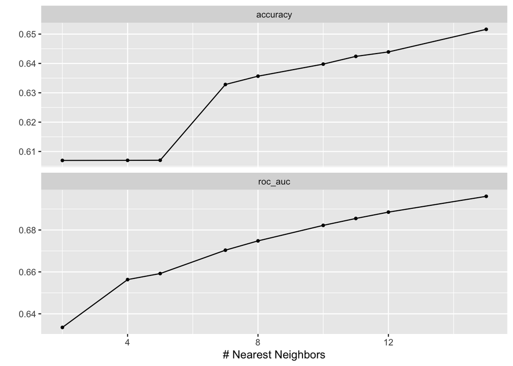

```r
# print results
knn_results = read_rds(file="project_knn_results.rds")
knn_results %>%
  autoplot()
```

Here, my roc_auc curve is constantly increasing which is awesome This tells us that the higher number of nearest neighbors the higher roc_auc we will get, which is what is wanted. However, it does not look like it is going to reach higher than 0.7 which is not great.

### Random Forest

```r
# random forest model
rf_spec <- rand_forest(mtry = 5) %>%
  set_engine("ranger", importance = "impurity") %>%
  set_mode("classification")

# workflow
rf_wf <- workflow() %>%
  add_model(rf_spec %>% set_args(mtry = tune(), trees=tune(),min_n=tune())) %>%
  add_recipe(polparty_recipe)

# grid
set.seed(0120)
param_grid_rf <- grid_regular(trees(range = c(1, 100)), mtry(range = c(1, 5)),min_n(range = c(1, 5)),levels = 5)
```

```r
# tune model
tune_res_rf <- tune_grid(
  rf_wf,
  resamples = polparty_fold,
  grid = param_grid_rf,
  metrics = metric_set(roc_auc)
)

write_rds(tune_res_rf, file="project_rf_results2.rds")
```

Let’s see what it looks like:

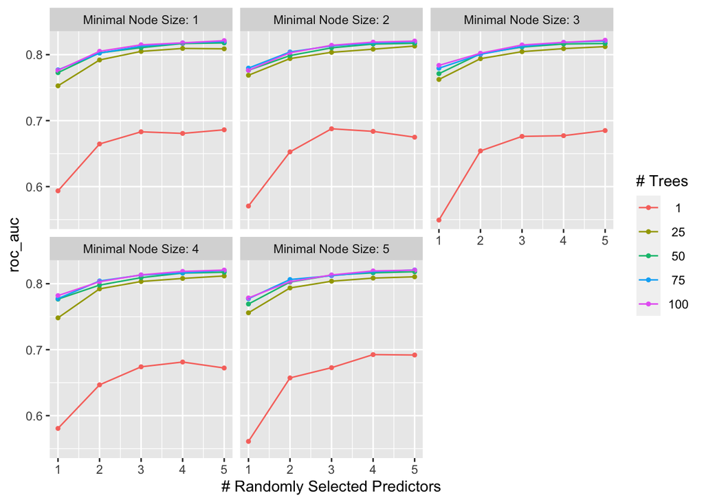

```r
# print results
rf_results <- read_rds(file="project_rf_results2.rds")
rf_results %>% autoplot()
```

Here we see that the more trees, the higher auc_roc.  
Similarly, the more predictors also shows better.  
The most optimal model appears to be with 100 trees and 5 predictors.  
The node size does not seem to change much.

### Boosted Trees

```r
# model
boost_spec <- boost_tree() %>%
 set_mode("classification") %>%
 set_engine("xgboost")

# workflow
boost_wf <- workflow() %>%
  add_model(boost_spec %>% set_args(trees = tune())) %>%
  add_recipe(polparty_recipe)

set.seed(0120)
param_grid_boost <- grid_regular(trees(range = c(1, 2000)), levels = 10)
```

```r
# tune
tune_res_boost <- tune_grid(
  boost_wf,
  resamples = polparty_fold,
  grid = param_grid_boost,
  metrics = metric_set(roc_auc)
)
write_rds(tune_res_boost, file="project_boost_results2.rds")
```

Let’s see it:

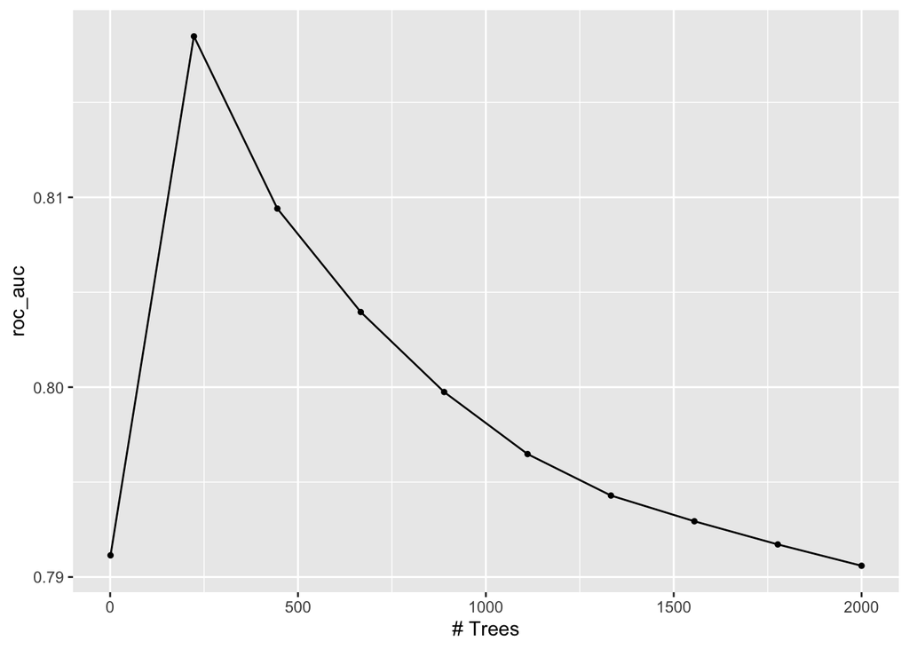

```r
# print results
boost_results <- read_rds(file="project_boost_results2.rds")
boost_results %>% autoplot()
```

I see a clear best point here, around 240 trees where we see the roc_auc around .819. This was interesting to me to because I initially assumed more trees would be better, but this plot shows that is not the case.  
I learned that in fact the number of trees does not have much of an impact.  
With full transparency, I also learned that I should have tuned learn_rate in order to fix my y axis. It currently only shows from .79 to .82 which is why the shift is so drastic. However after attempting to do this, the model would not run after nearly 10 hours, so I accepted defeat and left it without the tuning.